I need to first load in the libraries I will be using.

```r
library(tidyverse)
```

Create a subset of the penguin dataset that satisfies the following conditions.

First, I need to read in the dataset, from a link rather than from a place on my computer.

```r
penguins <- read.csv("https://raw.githubusercontent.com/eKissin/STA533_Kissin/main/w02-penguins.csv")
#penguins
```

Better version of plot from HW1, implementing ideas from the lecture:

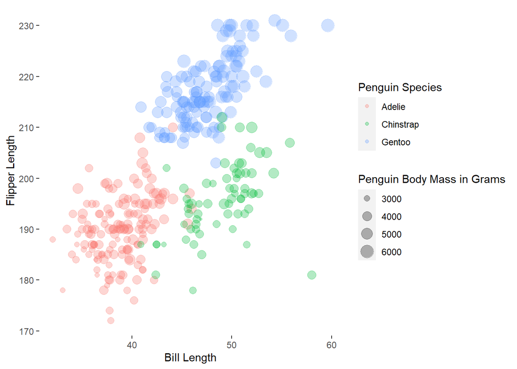

```r
ggplot(penguins)+geom_point(aes(bill_length_mm, flipper_length_mm, color=species, size=body_mass_g), alpha=0.3)+labs(x='Bill Length', y='Flipper Length')+scale_color_discrete(name='Penguin Species')+scale_size_continuous(name='Penguin Body Mass in Grams') + theme(panel.background = element_blank())#+ylim(0, 230)+xlim(0, 65)
```

Create a subset of the penguins data that does the following: delete all records with at least one missing component include adelie and gentoo penguins from biscoe and torgersen islands include OLNY penguins with body_mass_g less than 5000 grams and more than 3500 grams create a variable BMI=body_mass_g/4000 exclude variables X, sex, year, body_mass_g

```r
exc_vr <- c('X', 'sex', 'year', 'body_mass_g')
sub_penguins <- penguins %>% drop_na() %>% filter(species == 'Adelie' | species == 'Gentoo') %>% filter(island =='Biscoe' | island == 'Torgersen') %>% filter(3500<body_mass_g & 5000>body_mass_g)%>%mutate(BMI=body_mass_g/4000)%>%select(-exc_vr)
```

```
## Note: Using an external vector in selections is ambiguous.
## i Use `all_of(exc_vr)` instead of `exc_vr` to silence this message.
## i See <https://tidyselect.r-lib.org/reference/faq-external-vector.html>.
```

```r
#sub_penguins
```

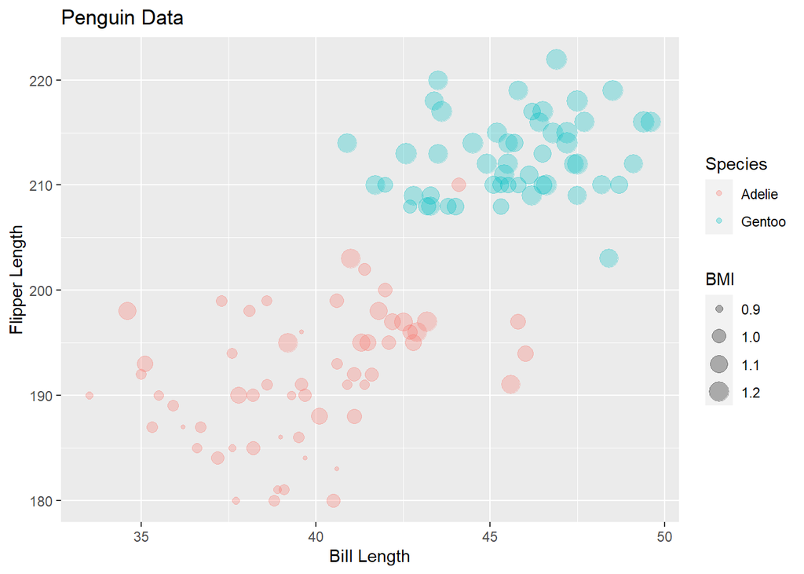

```r
ggplot(sub_penguins, aes(bill_length_mm, flipper_length_mm))+geom_point(aes(color=species, size=BMI), alpha=0.3)+labs(x='Bill Length', y='Flipper Length')+ggtitle("Penguin Data")+scale_color_discrete(name='Species')
```